# Estimating variability: From A, B, C to Tau, Sigma, Psi

The large bar at the left side of the distribution is an artifact resulting from extreme proportions correct and limited time series length. Fold out the code block below for a more detailed explanation.

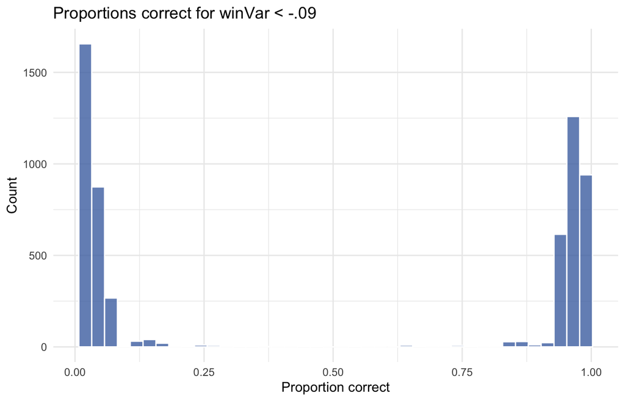

```r
# the large bar of winVar values below -.09 belongs to time series with
# extreme proportions correct
ggplot(data.frame(x = ran_p[winVar_ran < -.09]), aes(x = x)) +
  geom_histogram(bins = 40, fill = "#4C72B0", colour = "white", alpha = .8) +
  labs(title = "Proportions correct for winVar < -.09",
       x = "Proportion correct", y = "Count") +
  theme_minimal()
```

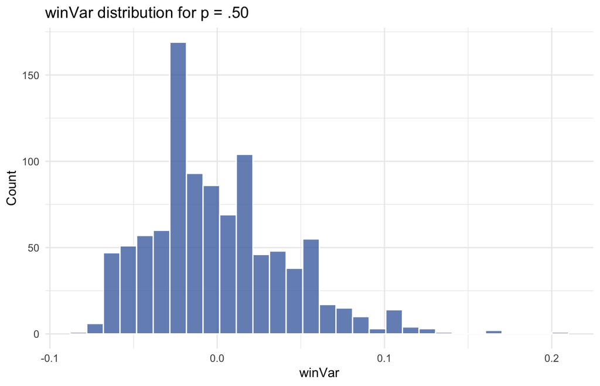

```r
# for p = .50 the distribution shows a similar skew as the full distribution.
# the skew exists because time series can deviate from 0 in the positive
# direction by extreme clustering of 1s and 0s, while negative deviations
# are limited because the expected winVar is already close to the theoretical
# minimum for random data
meas_50 <- winVar_ran[ran_p == .50]
ggplot(data.frame(x = meas_50), aes(x = x)) +
  geom_histogram(bins = 30, fill = "#4C72B0", colour = "white", alpha = .8) +
  labs(title = "winVar distribution for p = .50",
       x = "winVar", y = "Count") +
  theme_minimal()
```

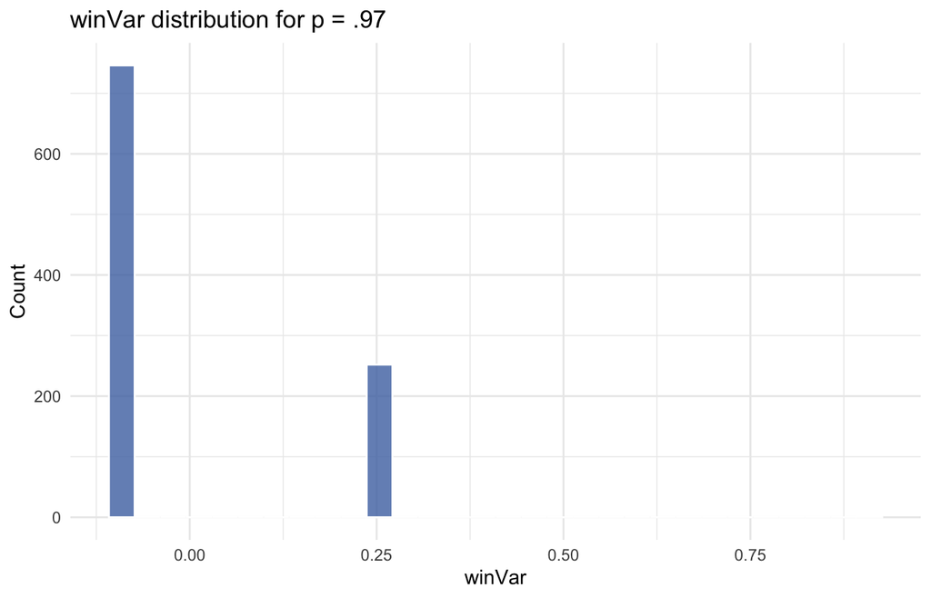

```r
# this effect is even stronger for extreme proportions correct: for p = .97,
# there are only 3 possible winVar values depending on whether the three 0s
# appear in different windows or 2-3 appear in the same window. The resulting
# large negative mode drives the leftward bar in the full distribution.
meas_97 <- winVar_ran[ran_p == .97]
ggplot(data.frame(x = meas_97), aes(x = x)) +
  geom_histogram(bins = 30, fill = "#4C72B0", colour = "white", alpha = .8) +
  labs(title = "winVar distribution for p = .97",
       x = "winVar", y = "Count") +
  theme_minimal()
```

In order to “compensate” for the small minority of extreme winVar values where 2 or 3 0s appear in the same window, the mode deviates quite strongly from 0 in the negative direction. The large negative bar in the distribution of all values combined is the result of these negative modes.

### 2.13.5 Correlations in realistic data

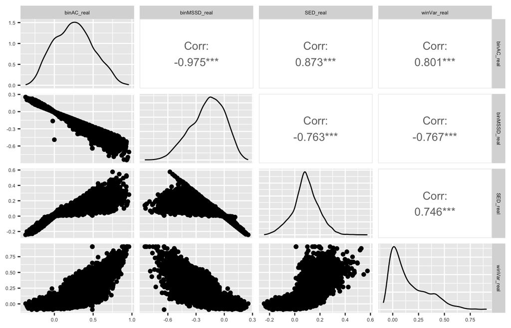

```r
# compute correlations in realistic data
real_meas = data.frame(binAC_real, binMSSD_real, SED_real, winVar_real)

GGally::ggpairs(real_meas) +
  theme(axis.text  = element_text(size = 5),
        strip.text = element_text(size = 5))
```

```r
cor(real_meas, use = "complete.obs") %>%
  round(2) %>%
  knitr::kable()
```

|  | binAC_real | binMSSD_real | SED_real | winVar_real |
| --- | --- | --- | --- | --- |
| binAC_real | 1.00 | -0.98 | 0.87 | 0.80 |
| binMSSD_real | -0.98 | 1.00 | -0.76 | -0.77 |
| SED_real | 0.87 | -0.76 | 1.00 | 0.75 |
| winVar_real | 0.80 | -0.77 | 0.75 | 1.00 |

# 3 Conclusion

Throughout this tutorial, we hope to have illustrated the breadth of statistical measures, each with different strengths and weaknesses, with which researchers can estimate cognitive variability across different data types. This will help further empirical investigation of cognitive variability across a wide range of contexts, tasks and settings. Depending on the scientific question, cognitive process studied, experimental task design and the type of data collected, researchers can make an informed choice among the available measures

# 4 Appendix

## 4.1 Software Citations

```r
library(grateful)
library(formattable)

pkgs <- cite_packages(
  output = "table",
  bib.file = "grateful-refs.bib",
  out.dir = getwd(),
  cite.tidyverse = TRUE,
  include.RStudio = FALSE
)

formattable(
  pkgs,
  table.attr = 'class="table table-striped" style="font-size:13px; font-family:Lato; width:80%"'
)
```

| Package | Version | Citation |
| --- | --- | --- |
| base | 4.5.1 | R Core Team (2025) |
| bayesplot | 1.14.0 | Gabry et al. (2019); Gabry and Mahr (2025) |
| beepr | 2.0 | Bååth (2024) |
| brms | 2.23.0 | Bürkner (2017); Bürkner (2018); Bürkner (2021) |
| cmdstanr | 0.9.0.9000 | Gabry et al. (2025) |
| datawizard | 1.3.1 | Patil et al. (2022) |
| easyRT | 0.1.0 | Makowski (2026b) |
| easystats | 0.7.6 | Lüdecke et al. (2022) |
| effects | 4.2.5 | Fox (2003); Fox and Hong (2009); Fox and Weisberg (2018); Fox and Weisberg (2019) |
| ExGaussEstim | 0.1.2 | SLAOUI et al. (2023) |
| formattable | 0.2.1 | Ren and Russell (2021) |
| GGally | 2.4.0 | Schloerke et al. (2025) |
| ggdist | 3.3.3 | Kay (2024a); Kay (2025) |
| kableExtra | 1.4.0 | Zhu (2024) |
| knitr | 1.50 | Xie (2014); Xie (2015); Xie (2025) |
| lme4 | 1.1.37 | Bates et al. (2015) |
| MASS | 7.3.65 | Venables and Ripley (2002) |
| pacman | 0.5.1 | Rinker and Kurkiewicz (2018) |
| patchwork | 1.3.2 | Pedersen (2025) |
| posterior | 1.6.1 | Vehtari et al. (2021); Lambert and Vehtari (2022); Margossian et al. (2024); Vehtari et al. (2024); Bürkner et al. (2025) |
| pracma | 2.4.6 | Borchers (2025) |
| psych | 2.5.6 | William Revelle (2025) |
| remotes | 2.5.0 | Csárdi et al. (2024) |
| reshape2 | 1.4.4 | Wickham (2007) |
| rmarkdown | 2.29 | Xie, Allaire, and Grolemund (2018); Xie, Dervieux, and Riederer (2020); Allaire et al. (2024) |
| tidybayes | 3.0.7 | Kay (2024b) |
| tidyverse | 2.0.0 | Wickham et al. (2019) |

## 4.3 References

Allaire, JJ, Yihui Xie, Christophe Dervieux, Jonathan McPherson, Javier Luraschi, Kevin Ushey, Aron Atkins, et al. 2024. *rmarkdown: Dynamic Documents for r*. https://github.com/rstudio/rmarkdown.

Bååth, Rasmus. 2024. *beepr: Easily Play Notification Sounds on Any Platform*. https://doi.org/10.32614/CRAN.package.beepr.

Bates, Douglas, Martin Mächler, Ben Bolker, and Steve Walker. 2015. “Fitting Linear Mixed-Effects Models Using lme4.” *Journal of Statistical Software* 67 (1): 1–48. https://doi.org/10.18637/jss.v067.i01.

Borchers, Hans W. 2025. *pracma: Practical Numerical Math Functions*. https://doi.org/10.32614/CRAN.package.pracma.

Bürkner, Paul-Christian. 2017. “brms: An R Package for Bayesian Multilevel Models Using Stan.” *Journal of Statistical Software* 80 (1): 1–28. https://doi.org/10.18637/jss.v080.i01.

———. 2018. “Advanced Bayesian Multilevel Modeling with the R Package brms.” *The R Journal* 10 (1): 395–411. https://doi.org/10.32614/RJ-2018-017.

———. 2021. “Bayesian Item Response Modeling in R with brms and Stan.” *Journal of Statistical Software* 100 (5): 1–54. https://doi.org/10.18637/jss.v100.i05.

Bürkner, Paul-Christian, Jonah Gabry, Matthew Kay, and Aki Vehtari. 2025. “posterior: Tools for Working with Posterior Distributions.” https://mc-stan.org/posterior/.

Csárdi, Gábor, Jim Hester, Hadley Wickham, Winston Chang, Martin Morgan, and Dan Tenenbaum. 2024. *remotes: R Package Installation from Remote Repositories, Including “GitHub”*. https://doi.org/10.32614/CRAN.package.remotes.

Fox, John. 2003. “Effect Displays in R for Generalised Linear Models.” *Journal of Statistical Software* 8 (15): 1–27. https://doi.org/10.18637/jss.v008.i15.

Fox, John, and Jangman Hong. 2009. “Effect Displays in R for Multinomial and Proportional-Odds Logit Models: Extensions to the effects Package.” *Journal of Statistical Software* 32 (1): 1–24. https://doi.org/10.18637/jss.v032.i01.

Fox, John, and Sanford Weisberg. 2018. “Visualizing Fit and Lack of Fit in Complex Regression Models with Predictor Effect Plots and Partial Residuals.” *Journal of Statistical Software* 87 (9): 1–27. https://doi.org/10.18637/jss.v087.i09.

———. 2019. *An r Companion to Applied Regression*. 3rd ed. Thousand Oaks CA: Sage. https://www.john-fox.ca/Companion/index.html.

Gabry, Jonah, Rok Češnovar, Andrew Johnson, and Steve Bronder. 2025. *cmdstanr: R Interface to “CmdStan”*. https://github.com/stan-dev/cmdstanr.

Gabry, Jonah, and Tristan Mahr. 2025. “bayesplot: Plotting for Bayesian Models.” https://mc-stan.org/bayesplot/.

Gabry, Jonah, Daniel Simpson, Aki Vehtari, Michael Betancourt, and Andrew Gelman. 2019. “Visualization in Bayesian Workflow.” *J. R. Stat. Soc. A* 182: 389–402. https://doi.org/10.1111/rssa.12378.

Jahng, Seungmin, Phillip K. Wood, and Timothy J. Trull. 2008. “Analysis of Affective Instability in Ecological Momentary Assessment: Indices Using Successive Difference and Group Comparison via Multilevel Modeling.” *Psychological Methods* 13 (4): 354–75.

Kay, Matthew. 2024a. “ggdist: Visualizations of Distributions and Uncertainty in the Grammar of Graphics.” *IEEE Transactions on Visualization and Computer Graphics* 30 (1): 414–24. https://doi.org/10.1109/TVCG.2023.3327195.

———. 2024b. *tidybayes: Tidy Data and Geoms for Bayesian Models*. https://doi.org/10.5281/zenodo.1308151.

———. 2025. *ggdist: Visualizations of Distributions and Uncertainty*. https://doi.org/10.5281/zenodo.3879620.

Lambert, Ben, and Aki Vehtari. 2022. “Rstar: A Robust MCMC Convergence Diagnostic with Uncertainty Using Decision Tree Classifiers.” *Bayesian Analysis* 17 (2): 353–79. https://doi.org/10.1214/20-BA1252.

Lüdecke, Daniel, Mattan S. Ben-Shachar, Indrajeet Patil, Brenton M. Wiernik, Etienne Bacher, Rémi Thériault, and Dominique Makowski. 2022. “easystats: Framework for Easy Statistical Modeling, Visualization, and Reporting.” *CRAN*. https://doi.org/10.32614/CRAN.package.easystats.

Makowski, Dominique. 2026b. *easyRT: Tools and Examples for Fitting (Hierarchical) Drift Diffusion Models in r*. https://github.com/DominiqueMakowski/easyRT.

———. 2026a. *easyRT: Tools and Examples for Fitting (Hierarchical) Drift Diffusion Models in r*.

Margossian, Charles C., Matthew D. Hoffman, Pavel Sountsov, Lionel Riou-Durand, Aki Vehtari, and Andrew Gelman. 2024. “Nested Rhat: Assessing the Convergence of Markov Chain Monte Carlo When Running Many Short Chains.” *Bayesian Analysis*. https://doi.org/10.1214/24-BA1453.

Patil, Indrajeet, Dominique Makowski, Mattan S. Ben-Shachar, Brenton M. Wiernik, Etienne Bacher, and Daniel Lüdecke. 2022. “datawizard: An R Package for Easy Data Preparation and Statistical Transformations.” *Journal of Open Source Software* 7 (78): 4684. https://doi.org/10.21105/joss.04684.

Pedersen, Thomas Lin. 2025. *patchwork: The Composer of Plots*. https://doi.org/10.32614/CRAN.package.patchwork.

R Core Team. 2025. *R: A Language and Environment for Statistical Computing*. Vienna, Austria: R Foundation for Statistical Computing. https://www.R-project.org/.

Ren, Kun, and Kenton Russell. 2021. *formattable: Create “Formattable” Data Structures*. https://doi.org/10.32614/CRAN.package.formattable.

Rinker, Tyler W., and Dason Kurkiewicz. 2018. *pacman: Package Management for R*. Buffalo, New York. http://github.com/trinker/pacman.

Schloerke, Barret, Di Cook, Joseph Larmarange, Francois Briatte, Moritz Marbach, Edwin Thoen, Amos Elberg, and Jason Crowley. 2025. *GGally: Extension to “ggplot2”*. https://doi.org/10.32614/CRAN.package.GGally.

SLAOUI, Yousri, Abir EL HAJ, Alandra ZAKKOUR, Caroline BORDES, Cyril PERRET, and Jean DUMONCEL. 2023. *ExGaussEstim: Quantile Maximization Likelihood Estimation and Bayesian Ex-Gaussian Estimation*. https://doi.org/10.32614/CRAN.package.ExGaussEstim.

Vehtari, Aki, Andrew Gelman, Daniel Simpson, Bob Carpenter, and Paul-Christian Bürkner. 2021. “Rank-Normalization, Folding, and Localization: An Improved Rhat for Assessing Convergence of MCMC (with Discussion).” *Bayesian Analysis* 16 (2): 667–718.

Vehtari, Aki, Daniel Simpson, Andrew Gelman, Yuling Yao, and Jonah Gabry. 2024. “Pareto Smoothed Importance Sampling.” *Journal of Machine Learning Research* 25 (72): 1–58.

Venables, W. N., and B. D. Ripley. 2002. *Modern Applied Statistics with s*. Fourth. New York: Springer. https://www.stats.ox.ac.uk/pub/MASS4/.

Wickham, Hadley. 2007. “Reshaping Data with the reshape Package.” *Journal of Statistical Software* 21 (12): 1–20. http://www.jstatsoft.org/v21/i12/.

Wickham, Hadley, Mara Averick, Jennifer Bryan, Winston Chang, Lucy D’Agostino McGowan, Romain François, Garrett Grolemund, et al. 2019. “Welcome to the tidyverse.” *Journal of Open Source Software* 4 (43): 1686. https://doi.org/10.21105/joss.01686.

William Revelle. 2025. *psych: Procedures for Psychological, Psychometric, and Personality Research*. Evanston, Illinois: Northwestern University. https://CRAN.R-project.org/package=psych.

Xie, Yihui. 2014. “knitr: A Comprehensive Tool for Reproducible Research in R.” In *Implementing Reproducible Computational Research*, edited by Victoria Stodden, Friedrich Leisch, and Roger D. Peng. Chapman; Hall/CRC.

———. 2015. *Dynamic Documents with R and Knitr*. 2nd ed. Boca Raton, Florida: Chapman; Hall/CRC. https://yihui.org/knitr/.

———. 2025. *knitr: A General-Purpose Package for Dynamic Report Generation in R*. https://yihui.org/knitr/.

Xie, Yihui, J. J. Allaire, and Garrett Grolemund. 2018. *R Markdown: The Definitive Guide*. Boca Raton, Florida: Chapman; Hall/CRC. https://bookdown.org/yihui/rmarkdown.

Xie, Yihui, Christophe Dervieux, and Emily Riederer. 2020. *R Markdown Cookbook*. Boca Raton, Florida: Chapman; Hall/CRC. https://bookdown.org/yihui/rmarkdown-cookbook.

Zhu, Hao. 2024. *kableExtra: Construct Complex Table with “kable” and Pipe Syntax*. https://doi.org/10.32614/CRAN.package.kableExtra.